# REDDIT SENTIMENT PROJECT

Richard More | Quan Le | Hao Nguyen | Anirudh Chaudhary

Date: 02/26/2020

### I. INTRODUCTION

#### A. Overview

We choose https://www.reddit.com/ as our primary platform for the sentiment analysis. We chose Corona virus as our subreddit due to the current outbreak. We would like to explore what is the Reddit community’s main reaction to this topic.

#### B. Data Source

We will use RedditExtractoR, tidyverse, and other relevant libraries. RedditExtractoR (or Reddit Data Extraction Toolkit is created by Ivan Rivera) is the package with which we can fetch the thread and content through the Reddit URL. For more information, please visit https://www.reddit.com/dev/api.

#### C. Summary

Comments, Comment’s scores, and post scores are the attributes we will work with. After cleaning the stopwords and joinging the tokens with Bing, NRC, and Afinn, we analyzed the trend of Corona Virus through the distribution of Sentiments and comments about Corona and World news over time.

#### D. Modeling

Based on these analysis, we try to predict the comment scores with Gradient Boosting Machines and Linear Regression with the H2O instance.

#### E. Libraries

The following libraries will be used in our projects

```r
library(RedditExtractoR)
library(kableExtra)
library(tidyverse)
library(wordcloud)
library(ggthemes)
library(tidytext)
library(recipes)
library(skimr)
library(h2o)
library(RCurl)
```

### II. REDDIT SENTIMENT ANALYSIS

#### A. Retrieve Reddit Information

```r
r <- reddit_urls(subreddit = "Coronavirus", page_threshold = 20)
rc <- reddit_content(r$URL)
```

```r
summary.df <- tibble(Columns = integer(), Rows = integer())
summary.df <- add_row(summary.df, Columns = length(rc), Rows = nrow(rc))

summary.df %>%
  kable() %>%
  add_header_above(header = c("Data summary" = length(summary.df)),
                   bold = TRUE,
                   font_size = "larger",
                   align = "left") %>%
  kable_styling(bootstrap_options = c("striped", "hover"))
```

| Data summary Columns | Data summary Rows |
| --- | --- |
| 18 | 13387 |

We have downloaded 20 pages of Reddit post’s comments, generating more than 10 thousand observations to work with. The data has 18 columns, out of which we will use only 3, comment, comment_score, and post_score.

```r
rc_rel <- rc[c("comment", "comment_score", "post_score")]
rc_rel <- mutate(rc_rel, id = rownames(rc_rel))

rc_rel[, c(4, 3, 2, 1)] %>%
  head(n = 5) %>%
  kable() %>%
  add_header_above(header = c("Initial look at the data" = length(rc_rel)),
                   bold = TRUE,
                   font_size = "larger",
                   align = "left") %>%
  kable_styling(bootstrap_options = c("striped", "hover"))
```

| Initial look at the data id | Initial look at the data post_score | Initial look at the data comment_score | Initial look at the data comment |
| --- | --- | --- | --- |
| 1 | 67 | 1 | This has already been posted. Please follow the link posted by another user. Thanks! |
| 2 | 67 | 37 | This is just testing for safety. Then we have to do a trial to see if it works. Then we have to begin production and roll it out. And all of this is IF everything goes well. If everything goes well, i… |
| 3 | 67 | 15 | Let’s hope for the best. |
| 4 | 67 | 3 | Where do these trials take place? |
| 5 | 67 | 3 | I believe at NIH |

#### B. Clean and Transform Sentiment

```r
tokens <- rc_rel %>%
  unnest_tokens(output = word, input = comment)

sw = get_stopwords()
cleaned_tokens <- tokens %>%
  filter(!word %in% sw$word)

nums <- cleaned_tokens %>%
  filter(str_detect(word, "^[0-9]|http[s]?|.com$")) %>%
  select(word) %>% unique()

cleaned_tokens <- cleaned_tokens %>%
  filter(!word %in% nums$word)

rare <- cleaned_tokens %>%
  count(word) %>%
  filter(n < 10) %>%
  select(word) %>%
  unique()

cleaned_tokens <- cleaned_tokens %>%
  filter(!word %in% rare$word)
```

#### C. WordCloud Visualization

Wordcloud all cleaned tokens

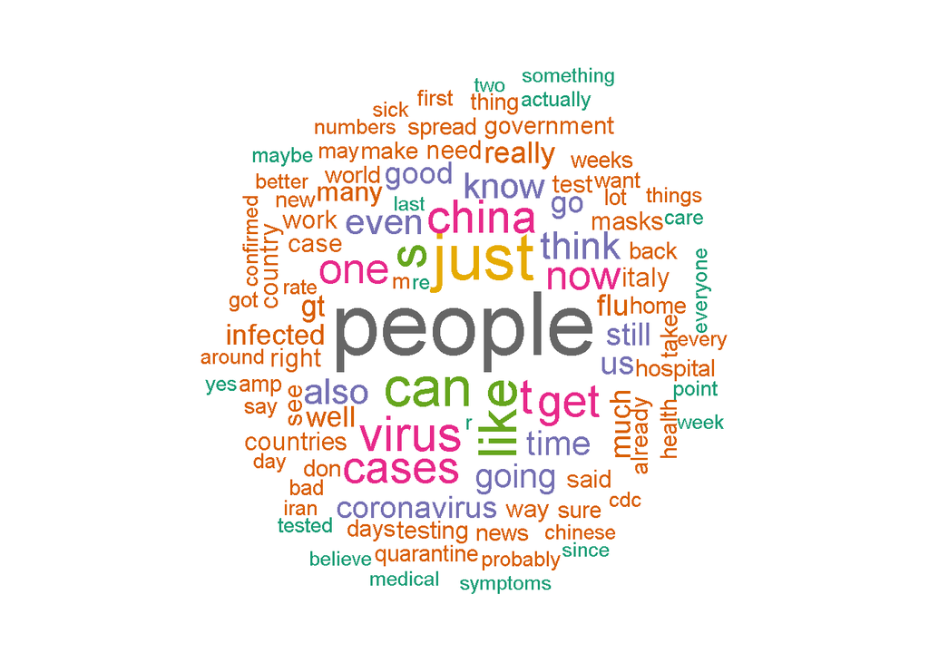

```r
pal <- brewer.pal(8,"Dark2")
cleaned_tokens %>%
  count(word) %>%
  with(wordcloud(word, n, random.order = FALSE, max.words = 100, colors = pal))
```

Join tokens with Bing, NRC, and Afinn

```r
sent_reviews = cleaned_tokens %>%
  left_join(get_sentiments("nrc")) %>%
  rename(nrc = sentiment) %>%
  left_join(get_sentiments("bing")) %>%
  rename(bing = sentiment) %>%
  left_join(get_sentiments("afinn")) %>%
  rename(afinn = value)
```

#### D. Sentiment Visualization

Sentiment for the word “corona” is not present in the above mentioned 3 sentiment lexicons, so we have to add our own.

```r
sent_reviews <- sent_reviews %>%
  mutate(bing = ifelse(word == "corona", "negative", bing)) %>%
  mutate(nrc = ifelse(word == "corona", "negative", nrc))
```

##### Bing Lexicon visualization

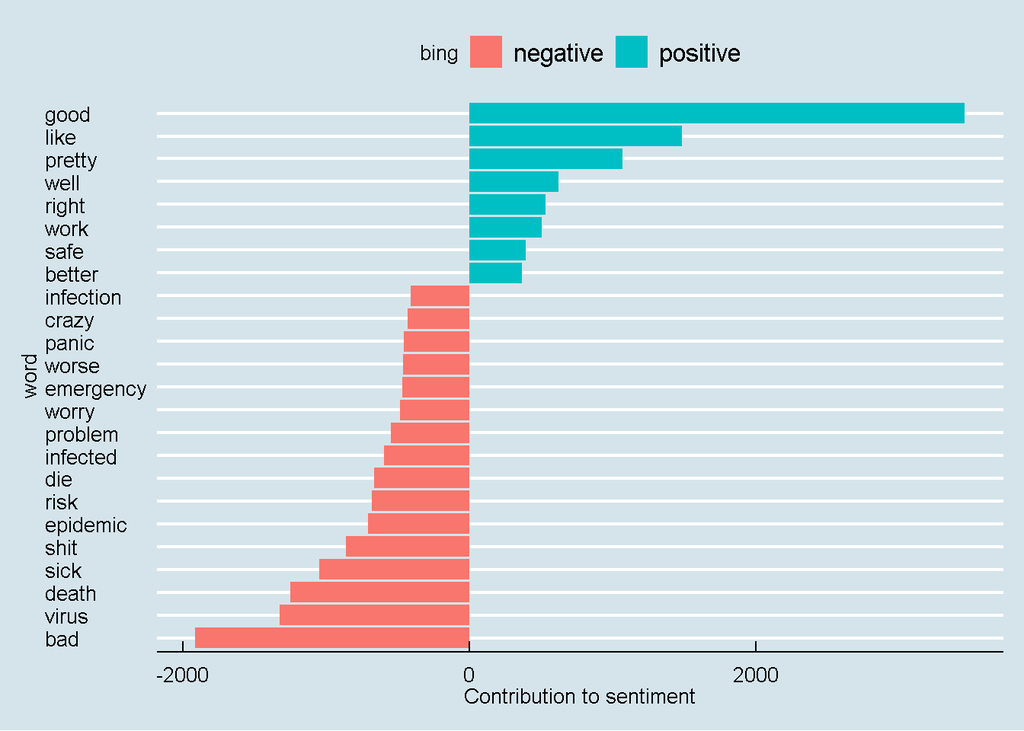

```r
bing_word_counts <- sent_reviews %>%
  filter(!is.na(bing)) %>%
  count(word, bing, sort = TRUE)

bing_word_counts %>%
  filter(n > 350) %>%
  mutate(n = ifelse(bing == "negative", -n, n)) %>%
  mutate(word = reorder(word, n)) %>%
  ggplot(aes(word, n, fill = bing)) +
    geom_col() +
    coord_flip() +
    labs(y = "Contribution to sentiment") +
    theme_economist()
```

##### NRC Lexicon visualization

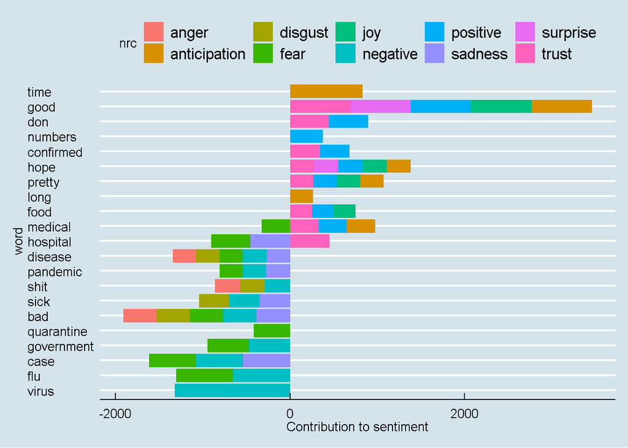

```r
nrc_word_counts <- sent_reviews %>%
  filter(!is.na(nrc)) %>%
  count(word, nrc, sort = TRUE)

nrc_word_counts %>%
  filter(n > 250) %>%
  mutate(n = ifelse(nrc %in%
                      c("negative", "fear", "anger", "sadness", "disgust"),
                    -n,
                    n)) %>%
  mutate(word = reorder(word, n)) %>%
  ggplot(aes(word, n, fill = nrc)) +
    geom_col() +
    coord_flip() +
    labs(y = "Contribution to sentiment") +
    theme_economist()
```

##### Distribution of sentiments

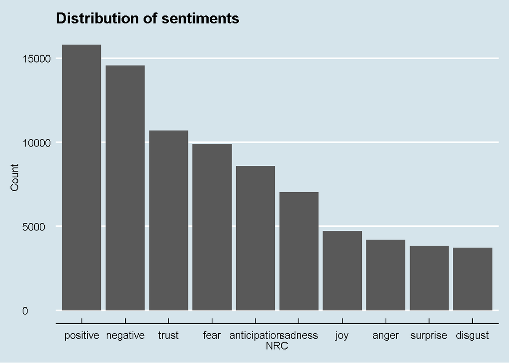

```r
sent_reviews %>%
  filter(!is.na(nrc)) %>%
  group_by(nrc) %>%
  summarise(count = n()) %>%
  ggplot(., aes(x = reorder(nrc, -count), y = count)) +
    geom_bar(stat = "identity") +
    xlab("NRC") +
    ylab("Count") +
    labs(title = "Distribution of sentiments") +
    theme_economist()
```

#### E. Chart for Concern of Corona Virus Overtime on Reddit

In this section we are analyzing the trend about the Corona virus.

The following 2 code chunks are not run when creating the final HTML, but are used to create the CSV for aggregation.

Set up the code to aggregate number of comment about World News and Corona everyday

```r
df_corona <- rc %>%
  filter(str_detect(title,"corona|Corona|CORONA|2019-nCOV") |
         str_detect(title,"COVID-19|Covid-19|covid-19")) %>%
  select(comm_date) %>%
  group_by(comm_date) %>%
  count(comm_date)

colnames(df_corona) <- c("Date", "Count_Corona")

df_world <- rc %>%
  select(comm_date) %>%
  group_by(comm_date) %>%
  count(comm_date)

colnames(df_world) <- c("Date", "Count_World")

df_export <- inner_join(df_world, df_corona, by = "Date")

if (file.exists("corona_over_time.csv") == TRUE){
  write.table(df_export,"corona_over_time.csv",
              append = TRUE, col.names = FALSE, sep = ",", row.names = FALSE)
} else {
  write.table(df_export,"corona_over_time.csv",
              append = FALSE, col.names = TRUE, sep = ",", row.names = FALSE)
}
```

Code to create a daily schedule for Corona aggregation

```r
library(taskscheduleR)
myscript <- system.file("reddit_corona.R")

taskscheduler_create(taskname = "CORONA_UPDATE",
                     rscript = "C:/Users/JNK4QBK/Desktop/reddit_corona.R",
                     schedule = "DAILY",
                     starttime = "23:50",
                     startdate = format(Sys.Date() + 1, "%d/%m/%Y"))
```

Import csv of Corona aggregation and visualize the results from the past several days

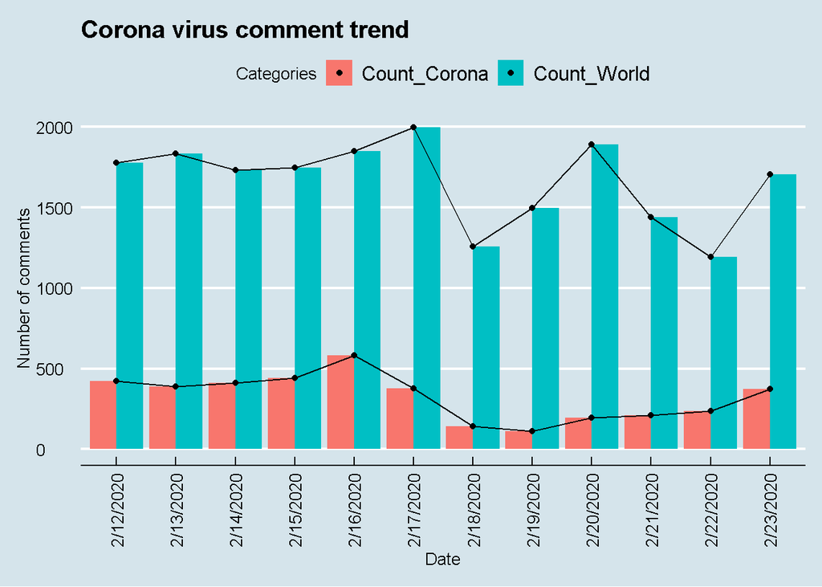

```r
urlfile="https://raw.githubusercontent.com/hnguyen154/RedditBigDataProject/master/corona_over_time.csv"

x <- getURL(urlfile)
df_corona_plot <- read.csv(text = x)

df_plot <- df_corona_plot %>%
  gather("Count_Corona", "Count_World", key = "Categories", value = "Total_Comments")

ggplot(df_plot, aes(x = Date, y = Total_Comments, fill = Categories)) +
  geom_bar(position = "dodge", stat = "identity") +
  geom_line(aes(x=Date, y=Total_Comments, group=Categories)) +
  geom_point() +
  ylab("Number of comments") +
  labs(title = "Corona virus comment trend") +
  theme_economist() +
  theme(axis.text.x = element_text(angle = 90, hjust = 0, vjust = 0.5))
```

### III. REDDIT SENTIMENT MACHINE LEARNING

For the machine learning part we are trying to create a model that can predict a comment’s score based on the score of the parent post and the comment’s NRC sentiments (more specifically the distribution of the sentiment types, like 8 trust words and 2 anger words, etc.)

#### A. Preprocess Data for Machine Learning

In the first step we are pulling the sentiment results together for the individual comments for machine learning.

```r
sent_reviews <- sent_reviews %>%
  mutate(id = as.integer(id))

df0 <- sent_reviews %>%
  select("id", "post_score", "comment_score") %>%
  unique()

nrcs <- sent_reviews %>%
  select("nrc") %>%
  unique() %>%
  na.omit() %>%
  as.list()

for (nrcx in nrcs$nrc) {
  df1 <- sent_reviews %>%
    select("id", "nrc") %>%
    filter(nrc == nrcx) %>%
    group_by(id) %>%
    summarise(num = n()) %>%
    arrange(id)

  colnames(df1)[2] <- paste0("nrc_", nrcx)

  df0 <- full_join(df0, df1, by = "id")
}

df0 %>%
  head(n = 5) %>%
  kable() %>%
  add_header_above(header = c("Data for Machine Learning" = length(df0)),
                   bold = TRUE,
                   font_size = "larger",
                   align = "left") %>%
  kable_styling(bootstrap_options = c("striped", "hover"))
```

| Data for Machine Learning id | Data for Machine Learning post_score | Data for Machine Learning comment_score | Data for Machine Learning nrc_anticipation | Data for Machine Learning nrc_positive | Data for Machine Learning nrc_joy | Data for Machine Learning nrc_surprise | Data for Machine Learning nrc_trust | Data for Machine Learning nrc_disgust | Data for Machine Learning nrc_fear | Data for Machine Learning nrc_negative | Data for Machine Learning nrc_sadness | Data for Machine Learning nrc_anger |
| --- | --- | --- | --- | --- | --- | --- | --- | --- | --- | --- | --- | --- |
| 1 | 67 | 1 | NA | NA | NA | NA | NA | NA | NA | NA | NA | NA |
| 2 | 67 | 37 | 1 | 2 | NA | NA | NA | NA | NA | NA | NA | NA |
| 3 | 67 | 15 | 1 | 1 | 1 | 1 | 1 | NA | NA | NA | NA | NA |
| 4 | 67 | 3 | NA | NA | NA | NA | NA | NA | NA | NA | NA | NA |
| 5 | 67 | 3 | NA | NA | NA | NA | NA | NA | NA | NA | NA | NA |

```r
summary.df <- tibble(Columns = integer(), Rows = integer())
summary.df <- add_row(summary.df, Columns = length(df0), Rows = nrow(df0))

summary.df %>%
  kable() %>%
  add_header_above(header = c("Data summary" = length(summary.df)),
                   bold = TRUE,
                   font_size = "larger",
                   align = "left") %>%
  kable_styling(bootstrap_options = c("striped", "hover"))
```

| Data summary Columns | Data summary Rows |
| --- | --- |
| 13 | 13081 |

Preparing the data for machine learning.

```r
x_train_tbl <- df0 %>% select(-c(comment_score, id))
y_train_tbl <- df0 %>% select(comment_score)

x_train_tbl_skim = partition(skim(x_train_tbl))

rec_obj <- recipe(~ ., data = x_train_tbl) %>%
  step_meanimpute(all_numeric()) %>%
  prep(training = x_train_tbl)

x_train_processed_tbl <- bake(rec_obj, x_train_tbl)
```

#### B. Create Machine Learning Model

Initiate an H2O Intance

```r
h2o.init(nthreads = -1)
h2o.removeAll()

data_h2o <- as.h2o(
  bind_cols(y_train_tbl, x_train_processed_tbl),
  destination_frame= "train.hex"
)
```

Train, Test, Validate Split in 70%, 15%, and 15%.

```r
splits <- h2o.splitFrame(data = data_h2o,
                         ratios = c(0.7, 0.15),
                         seed = 1234)
train_h2o <- splits[[1]]
valid_h2o <- splits[[2]]
test_h2o  <- splits[[3]]
```

#### C. Gradient Boosting Model

```r
y <- "comment_score"
x <- setdiff(names(train_h2o), y)

hyper_prms <- list(
  ntrees = c(45, 50, 55),
  learn_rate = c(0.1, 0.2),
  max_depth = c(20, 25)
)

grid_gbm <- h2o.grid(
  grid_id="grid_gbm",
  algorithm = "gbm",
  training_frame = train_h2o,
  validation_frame = valid_h2o,
  x = x,
  y = y,
  sample_rate = 0.7,
  col_sample_rate = 0.7,
  stopping_rounds = 2,
  stopping_metric = "RMSE",
  stopping_tolerance = 0.0001,
  score_each_iteration = T,
  model_id = "gbm_covType3",
  balance_classes = T,
  seed = 5000,
  hyper_params = hyper_prms
)
```

Get the best model and the metrics for that model from the grid

```r
gbm_grid <- h2o.getGrid("grid_gbm", sort_by = "rmse", decreasing = FALSE)
gbm_best_model <- h2o.getModel(gbm_grid@summary_table$model_ids[1])

gbm_metrics.df <- tibble(metric = character(), train = double(), valid = double())
gbm_metrics.df <- add_row(gbm_metrics.df,
                      metric = "R^2",
                      train = h2o.r2(gbm_best_model, train = TRUE),
                      valid = h2o.r2(gbm_best_model, valid = TRUE)
                      )
gbm_metrics.df <- add_row(gbm_metrics.df,
                      metric = "MSE",
                      train = h2o.mse(gbm_best_model, train = TRUE),
                      valid = h2o.mse(gbm_best_model, valid = TRUE)
                      )
gbm_metrics.df <- add_row(gbm_metrics.df,
                      metric = "RMSE",
                      train = h2o.rmse(gbm_best_model, train = TRUE),
                      valid = h2o.rmse(gbm_best_model, valid = TRUE)
                      )
gbm_metrics.df <- add_row(gbm_metrics.df,
                      metric = "Mean Residual Deviance",
                      train = h2o.mean_residual_deviance(gbm_best_model, train = TRUE),
                      valid = h2o.mean_residual_deviance(gbm_best_model, valid = TRUE)
                      )

gbm_metrics.df %>%
  kable() %>%
  add_header_above(header = c("Metrics" = length(gbm_metrics.df)),
                   bold = TRUE,
                   font_size = "larger") %>%
  kable_styling(bootstrap_options = c("striped", "hover"))
```

| Metrics metric | Metrics train | Metrics valid |
| --- | --- | --- |
| R^2 | 0.0893456 | 0.0006895 |
| MSE | 196.1211614 | 334.0398999 |
| RMSE | 14.0043265 | 18.2767585 |
| Mean Residual Deviance | 196.1211614 | 334.0398999 |

#### D. Linear Regression Model

```r
hyper_params <- list(
  alpha = c(0, .25, .5, .75, .1)
)

grid <- h2o.grid(
  grid_id = "grid_lr",
  algorithm = "glm",
  training_frame = train_h2o,
  validation_frame = valid_h2o,
  x = x,
  y = y,
  hyper_params = hyper_params,
  search_criteria = list(strategy = "Cartesian")
)
```

Get the best model and the metrics for that model from the grid

```r
lr_grid <- h2o.getGrid("grid_lr", sort_by = "rmse", decreasing = FALSE)
lr_best_model <- h2o.getModel(lr_grid@summary_table$model_ids[1])

lr_metrics.df <- tibble(metric = character(), train = double(), valid = double())
lr_metrics.df <- add_row(lr_metrics.df,
                      metric = "R^2",
                      train = h2o.r2(lr_best_model, train = TRUE),
                      valid = h2o.r2(lr_best_model, valid = TRUE)
                      )
lr_metrics.df <- add_row(lr_metrics.df,
                      metric = "MSE",
                      train = h2o.mse(lr_best_model, train = TRUE),
                      valid = h2o.mse(lr_best_model, valid = TRUE)
                      )
lr_metrics.df <- add_row(lr_metrics.df,
                      metric = "RMSE",
                      train = h2o.rmse(lr_best_model, train = TRUE),
                      valid = h2o.rmse(lr_best_model, valid = TRUE)
                      )
lr_metrics.df <- add_row(lr_metrics.df,
                      metric = "Mean Residual Deviance",
                      train = h2o.mean_residual_deviance(lr_best_model, train = TRUE),
                      valid = h2o.mean_residual_deviance(lr_best_model, valid = TRUE)
                      )

lr_metrics.df %>%
  kable() %>%
  add_header_above(header = c("Metrics" = length(lr_metrics.df)),
                   bold = TRUE,
                   font_size = "larger") %>%
  kable_styling(bootstrap_options = c("striped", "hover"))
```

| Metrics metric | Metrics train | Metrics valid |
| --- | --- | --- |
| R^2 | 0.0209156 | 0.0190935 |
| MSE | 210.8584420 | 327.8879880 |
| RMSE | 14.5209656 | 18.1076776 |
| Mean Residual Deviance | 210.8584420 | 327.8879880 |

#### E. Result and Discussion

After we fit the model Linear Regression and Gradient Boosting model, we attempt to find the best model based on the RMSE in the report on validation data. The results show low R-Square and high RMSE for both GBM and Linear Model.